# Quicksort performance analysis

Ilya Meignan–Masson and Nour El hassane

2022-11-10

# Problem statement

Improve the experimental design and the performance evaluation of a simple parallel quicksort implementation. This would be done by taking into accout the replication and randomization concepts, so that we have reliable unbiaised evaluations.

# Experimental design

## Generate the arrays of parameters (number of execution repetitions and different array sizes)

```r
#replication
number_of_repetitions <- c(0:10)
sizes <- c("100","500", "1000","5000", "10000","50000", "100000")
```

## Generate the combinations

```r
#randomization
experiments <- crossing(number_of_repetitions, sizes)
experiments <- experiments[sample(1:nrow(experiments)), ]
experiments
```

```
## # A tibble: 77 × 2
##    number_of_repetitions sizes
##                    <int> <chr>
##  1                     0 100
##  2                     4 50000
##  3                     3 500
##  4                     6 100
##  5                     1 1000
##  6                     5 100000
##  7                     1 10000
##  8                     3 5000
##  9                     7 500
## 10                    10 100
## # … with 67 more rows
```

## Run the functions

```r
# store the experiments parameters in a csv file
write.csv(experiments, "../data/nour_2022-11-23/experiments.csv", row.names=FALSE)
```

# Analysis of the results

```r
df <- read.csv(file="../data/nour_2022-11-23/measurements_2.csv", sep=",",header = FALSE)
names(df) <- c('Size','Function','Execution_time')
summary(df)
```

```
##       Size           Function Execution_time
##  Min.   :   100   Min.   :0   Min.   :0.0000080
##  1st Qu.:   500   1st Qu.:0   1st Qu.:0.0001135
##  Median :  5000   Median :1   Median :0.0025880
##  Mean   : 23800   Mean   :1   Mean   :0.0078984
##  3rd Qu.: 50000   3rd Qu.:2   3rd Qu.:0.0166270
##  Max.   :100000   Max.   :2   Max.   :0.0431200
```

Calculate the execution time mean (sample mean) for each function

```r
sample_means <- df %>% group_by(Function) %>% summarise(Sn=mean(`Execution_time`))
sample_means
```

```
## # A tibble: 3 × 2
##   Function      Sn
##      <int>   <dbl>
## 1        0 0.00413
## 2        1 0.0156
## 3        2 0.00391
```

Wow!! It seems that the parallel quicksort is the worst algorithm! Let’s use the boxplot and confirm that using the Confidence Interval.

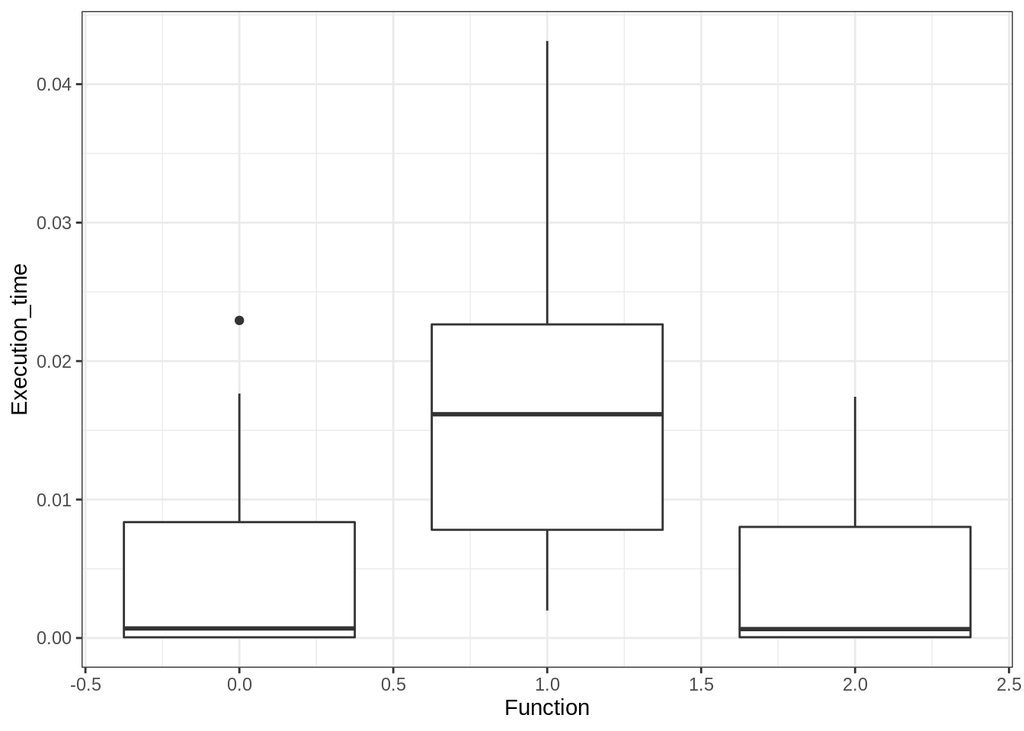

```r
ggplot(data=df,aes(x=Function,y=Execution_time, group=factor(Function)))+ geom_boxplot() + theme_bw()
```

```r
min_1 <-min(df$Execution_time[df$Function==1])
max_0 <- max(df$Execution_time[df$Function==0])
max_2 <- max(df$Execution_time[df$Function==2])
print(paste(min_1,max_0,max_2))
```

```
## [1] "0.001986 0.022936 0.017423"
```

Min execution time of the parallel quicksort is less than max sequential and max built-in. Thus, intervals overlap! Compare Var(1-0) to Var(1) and Var(0), and repeat the same for Var(1-2) to Var(1) and Var(2).

```r
df_0<-df$Execution_time[df$Function==0]
df_1<-df$Execution_time[df$Function==1]
df_2<-df$Execution_time[df$Function==2]
print(paste(var(df_1-df_0),var(df_1),var(df_0)))
```

```
## [1] "3.82509064111415e-05 9.17734432385509e-05 4.10405636852358e-05"
```

Var(1-0) is smaller than Var(1) and Var(0), so we can conclude that _0 < _1 with 95% of confidence.

```r
print(paste(var(df_1-df_2),var(df_1),var(df_2)))
```

```
## [1] "3.82729179446343e-05 9.17734432385509e-05 3.66615136619959e-05"
```

Var(1-2) is smaller than Var(1) but bigger than Var(2), so we need to consider the variable “1-2”.

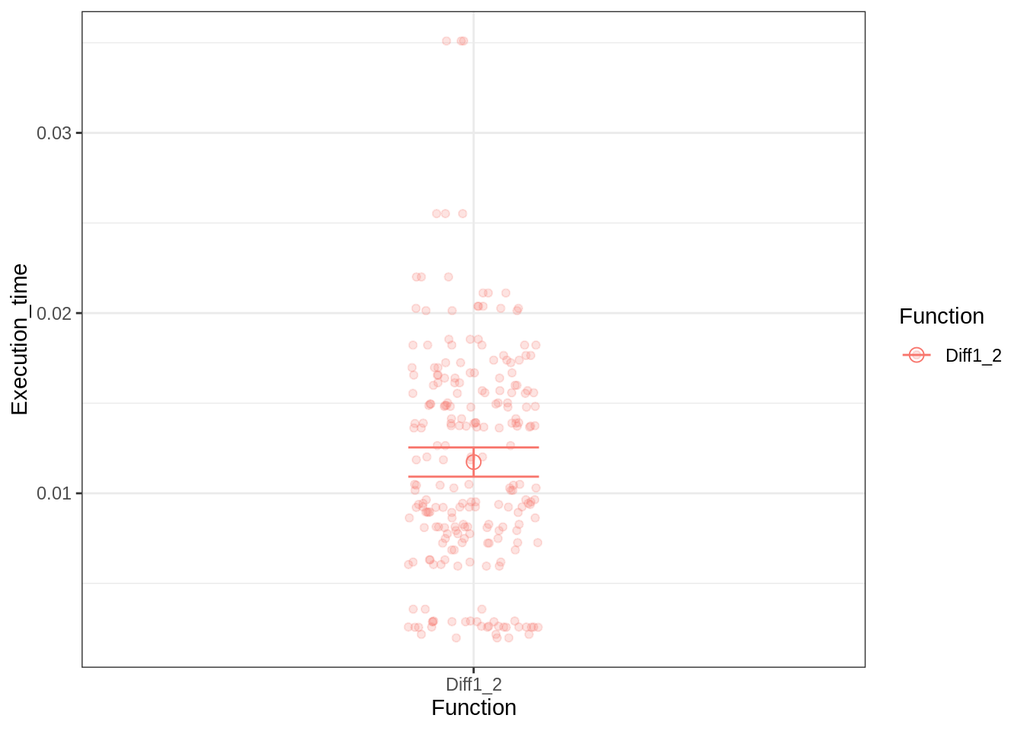

```r
df$Diff1_2=df_1-df_2
dfgg = df[c("Function","Execution_time","Diff1_2")] %>% gather(Function, Execution_time)
dfsum = dfgg %>% group_by(Function) %>% summarise(num = n(), mean = mean(Execution_time), sd = sd(Execution_time), se = 2*sd/sqrt(num))
ggplot(dfgg,aes(x=Function,y=Execution_time,color=Function))  + theme_bw() +
geom_jitter(alpha=.2,position = position_jitter(width = .1)) +
geom_errorbar(data=dfsum,width=.2,
aes(y=mean,ymin=mean-se,ymax=mean+se)) +
geom_point(data=dfsum,shape=21, size=3,aes(y=mean,color=Function))
```

We can see from the boxplot that E[1-2]>0 => E[1] > E[2]. We can deduce then, that C quicksort is better than the parallel quicksort.